# Devoir maison R, base de donnée : Cigar

Matteo Leolli, Come Mayinda Zobela, Alan Even, et Nicolas Ekanza-Mapengo

```r
knitr::opts_chunk$set(message = FALSE,
                      warning = FALSE,
                      fig.height = 4, fig.width = 5)
```

```r
library(readxl)
library(plm)
library(lmtest)
library(corrplot)
library(carData)
library(car)
library(stargazer)
```

```r
cigar <- read_xlsx("Cigar.xlsx")
```

# Introduction

1 - l’abréviation d’état;

2 - l’année;

3 - le prix par paquet de cigarettes;

4 - la population;

5 - la population de plus de 16 ans;

6 - l’indice des prix à la consommation;

7 - le revenu disponible par habitant;

8 - la vente de cigarettes en paquet par habitant;

9 - le prix minimum des cigarettes d’un paquet de cigarette dans les Etats limitrophes.

Avec ces variables disponibles, nous avons décider d’étudier le prix par paquet de cigarettes en fonction de certaines autres variables. Nous montrerons par la suite quels variables explicatives nous avons gardé. Pour l’instant, nous allons faire de la statistique descriptive sur les données.

```r
valmanquantes <- sum(is.na(cigar))
valmanquantes
```

```
## [1] 0
```

Et nous avons vérifié si des valeurs étaient manquantes juste avant, mais il n’y en a aucune.

# Statistiques descriptives

```r
str(cigar) # structure de la base de donnée
```

```
## tibble [1,380 x 9] (S3: tbl_df/tbl/data.frame)
##  $ etat    : num [1:1380] 1 1 1 1 1 1 1 1 1 1 ...
##  $ an      : num [1:1380] 63 64 65 66 67 68 69 70 71 72 ...
##  $ prix    : num [1:1380] 28.6 29.8 29.8 31.5 31.6 35.6 36.6 39.6 42.7 42.3 ...
##  $ pop     : num [1:1380] 3383 3431 3486 3524 3533 ...
##  $ pop16   : num [1:1380] 2236 2277 2328 2370 2394 ...
##  $ ipc     : num [1:1380] 30.6 31 31.5 32.4 33.4 34.8 36.7 38.8 40.5 41.8 ...
##  $ rdh     : num [1:1380] 1558 1684 1810 1915 2024 ...
##  $ ventes  : num [1:1380] 93.9 95.4 98.5 96.4 95.5 ...
##  $ priximin: num [1:1380] 26.1 27.5 28.9 29.5 29.6 32 32.8 34.3 35.8 37.4 ...
```

```r
head(cigar) # début de la base de donnée
```

| etat | an | prix | pop | pop16 | ipc | rdh | ventes | priximin |
| --- | --- | --- | --- | --- | --- | --- | --- | --- |
| 1 | 63 | 28.6 | 3383 | 2236.5 | 30.6 | 1558.305 | 93.9 | 26.1 |
| 1 | 64 | 29.8 | 3431 | 2276.7 | 31.0 | 1684.073 | 95.4 | 27.5 |
| 1 | 65 | 29.8 | 3486 | 2327.5 | 31.5 | 1809.842 | 98.5 | 28.9 |
| 1 | 66 | 31.5 | 3524 | 2369.7 | 32.4 | 1915.160 | 96.4 | 29.5 |
| 1 | 67 | 31.6 | 3533 | 2393.7 | 33.4 | 2023.546 | 95.5 | 29.6 |
| 1 | 68 | 35.6 | 3522 | 2405.2 | 34.8 | 2202.486 | 88.4 | 32.0 |

```r
tail(cigar) # fin de la base de donnée
```

| etat | an | prix | pop | pop16 | ipc | rdh | ventes | priximin |
| --- | --- | --- | --- | --- | --- | --- | --- | --- |
| 51 | 87 | 102.7 | 490.0 | 357.0 | 113.6 | 11113.93 | 110.4 | 106.2 |
| 51 | 88 | 112.9 | 479.0 | 353.0 | 118.3 | 11803.00 | 114.3 | 115.3 |
| 51 | 89 | 118.6 | 475.0 | 352.0 | 124.0 | 12399.00 | 111.4 | 123.0 |
| 51 | 90 | 129.5 | 470.9 | 348.9 | 130.7 | 13871.00 | 96.9 | 138.9 |
| 51 | 91 | 127.0 | 477.1 | 355.2 | 136.2 | 14675.00 | 109.1 | 143.6 |
| 51 | 92 | 155.1 | 483.3 | 360.5 | 140.3 | 15607.00 | 110.8 | 160.0 |

```r
summary(cigar) # sommaire de chaque variable de la base de donnée
```

```
##       etat             an            prix             pop
##  Min.   : 1.00   Min.   :63.0   Min.   : 23.40   Min.   :  319
##  1st Qu.:15.00   1st Qu.:70.0   1st Qu.: 34.77   1st Qu.: 1053
##  Median :26.50   Median :77.5   Median : 52.30   Median : 3174
##  Mean   :26.83   Mean   :77.5   Mean   : 68.70   Mean   : 4537
##  3rd Qu.:40.00   3rd Qu.:85.0   3rd Qu.: 98.10   3rd Qu.: 5280
##  Max.   :51.00   Max.   :92.0   Max.   :201.90   Max.   :30703
##      pop16              ipc             rdh            ventes
##  Min.   :  215.2   Min.   : 30.6   Min.   : 1323   Min.   : 53.4
##  1st Qu.:  781.2   1st Qu.: 38.8   1st Qu.: 3328   1st Qu.:107.9
##  Median : 2315.3   Median : 62.9   Median : 6281   Median :121.2
##  Mean   : 3366.6   Mean   : 73.6   Mean   : 7525   Mean   :124.0
##  3rd Qu.: 3914.3   3rd Qu.:107.6   3rd Qu.:11024   3rd Qu.:133.2
##  Max.   :22920.0   Max.   :140.3   Max.   :23074   Max.   :297.9
##     priximin
##  Min.   : 23.40
##  1st Qu.: 31.98
##  Median : 46.40
##  Mean   : 62.90
##  3rd Qu.: 90.50
##  Max.   :178.50
```

```r
# Nous aurions pu mettre la commande summary(cigar$prix) et faire cela pour toutes les
# variables mais grace à summary(cigar) toutes les informations sont données directement
# pour chaque variable.
```

Grâce à cette dernière commande, nous avons les données suivantes sur chaque variable : les principaux quartiles, la médiane, la moyenne, le minimum et le maximum. Avec ces données et nos idées, on a décidé d’écarter la variable Etat pour étudier le prix car elle nous semble peu intéressante. Les autres variables semblent intéressantes pour la création d’un modèle. Après la comparaison de modèles, peut être que certaines variables seront enlevés. Nous avons pensé à étudier la corrélation entre chaque variable, pour cela nous avons monté la matrice des corrélations suivante :

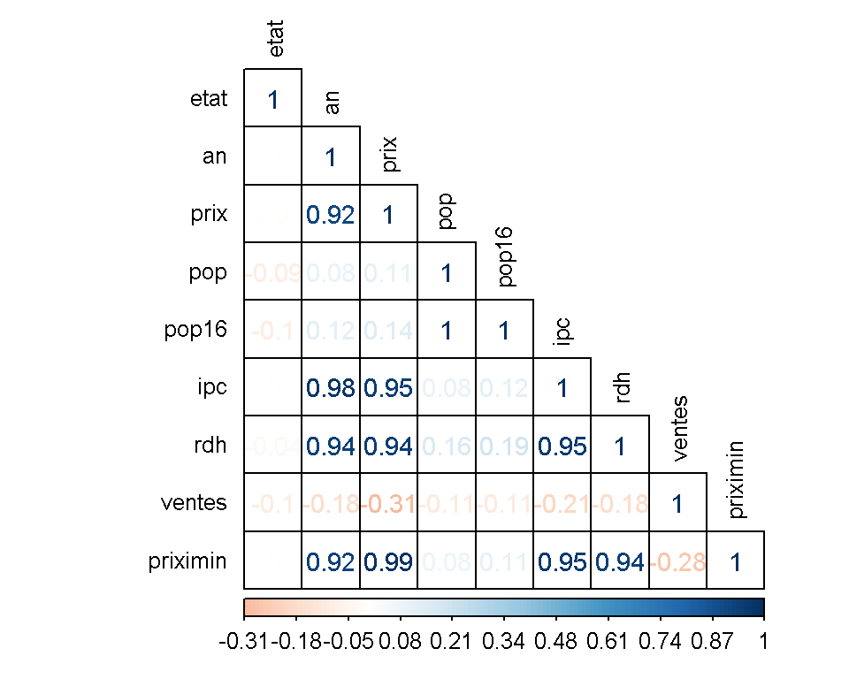

```r
corrplot(cor(cigar),type = "lower", method = "number", is.corr = FALSE,bg="white",title = "",
         cex.main=0.7, diag = TRUE,tl.cex=0.8,number.cex=0.9,shade.col="black", number.font = 1,
         col= NULL,addgrid.col = "black", rect.lwd = 2,tl.col = "black",tl.offset = 0.5,cl.ratio = 0.15)
```

Ce qui nous intéresse dans cette matrice, c’est la corrélation avec le prix par paquet de cigarettes et les autres variables. Plus la corrélation est proche de 1, plus il y a une relation linéaire positive entre les 2 variables. Plus la corrélation est proche de -1, plus il y a une relation linéaire négative entre les 2 variables. Si la corrélation est proche de 0, c’est qu’il n’y a pas de vrai relation entre les 2 variables. Donc grâce à cett matrice, on peut donc voir que le prix est fortement correlé avec l’année, l’IPC, le revenu disponible par habitant, et le prix minimum des cigarettes dans les Etats limitrophes. Concernant l’Etat la corrélation est très proche de 0, notre choix de l’enlever de notre futur modèle était donc une bonne intuition.

Nous avons ensuite fait des histogrammes sur les données pour essayer de visualiser un peu plus les données.

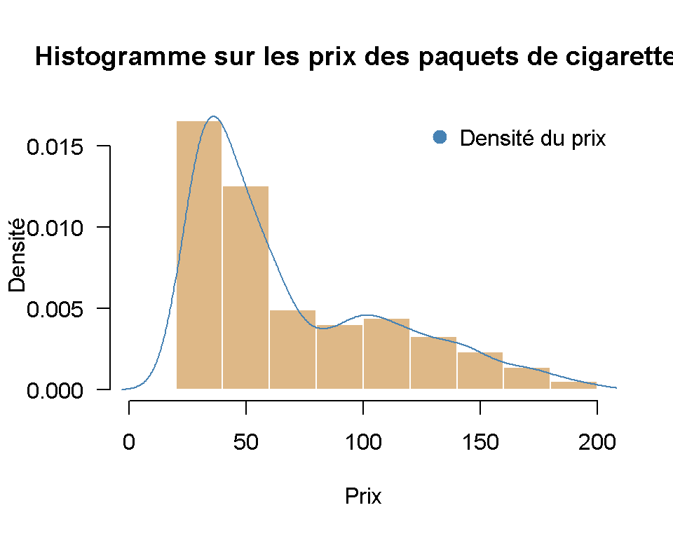

```r
hist(cigar$prix, freq = F, main = "Histogramme sur les prix des paquets de cigarettes",
     col = "burlywood", border = "white", las =1,
     xlab = "Prix", ylab = "Densité", xlim = c(0,200))
lines(density(cigar$prix, na.rm = TRUE), col = "steelblue")
legend("topright",
       legend= "Densité du prix", col="steelblue",
       pt.cex=2, pch=20, bty = "n")
```

Ici nous avons visualisé les prix des paquets de cigarettes avec un histogramme en rajoutant sa densité dans le graphique.

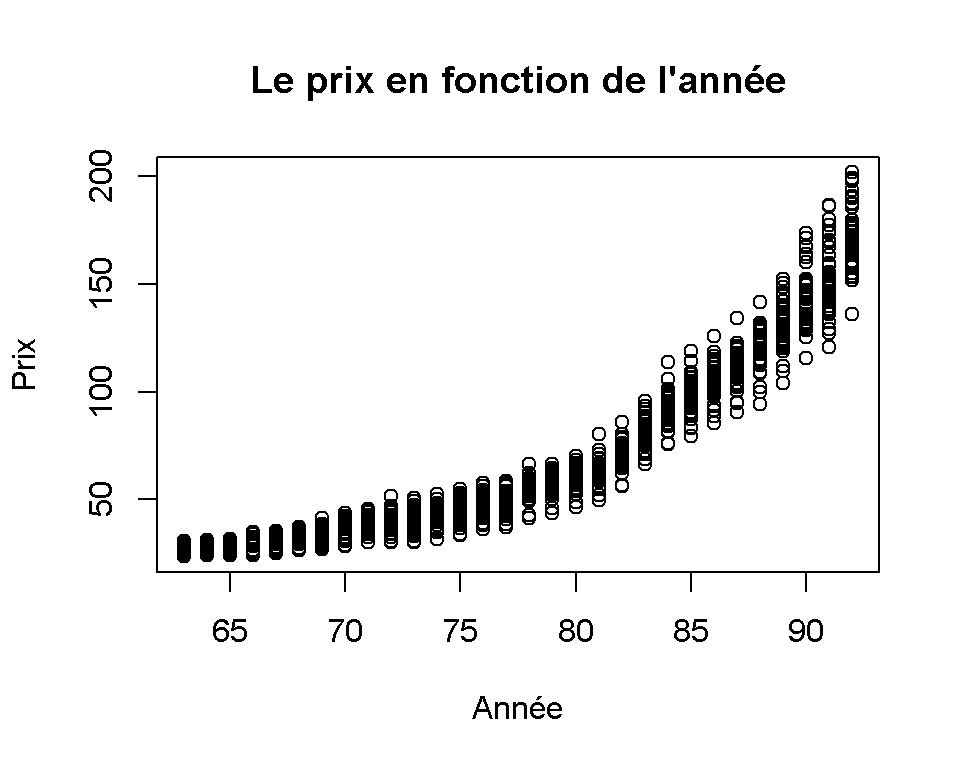

```r
plot(cigar$an, cigar$prix, main = "Le prix en fonction de l'année",
     ylab = "Prix", xlab = "Année")
```

Ce graphique nous montre bien que le prix a une évolution en fonction de l’année, et que cette évolution est croissante au fil du temps. D’autres graphiques comme celui ci ont été faits pour visualiser les liens entre le prix et les autres variables.

# Premier modèle

Pour le premier modèle, nous avons pensé faire une régression linéaire multiple avec comme variable expliqué le prix par paquet de cigarettes, et comme variables explicatives l’année, l’IPC, le revenu disponible par habitant, et le prix minimum des Etats limitrophes par paquet de cigarettes car c’était les variables les plus corrélés avec le prix. Mais nous avons pensé que la population de plus de 16 ans pouvait être une variable explicative au prix même si la corrélation n’était pas évidente suivant la matrice. Nous avons préféré choisir la population de plus de 16 ans que la population générale car on étudie le prix des cigarettes, en conséquence, peu d’individus ayant moins de 16 ans sont amenés à acheter des cigarettes. Nous avons donc essayé un modèle avec la variable population puis un autre sans.

Nous avons donc le premier modèle suivant:

```r
modele <- cigar$prix ~ log(cigar$rdh) + cigar$priximin + cigar$an + cigar$ipc + log(cigar$pop16)
estmodele <- lm(modele, data = cigar)
summary(estmodele)
```

```
##
## Call:
## lm(formula = modele, data = cigar)
##
## Residuals:
##     Min      1Q  Median      3Q     Max
## -28.727  -3.035  -0.056   3.152  33.776
##
## Coefficients:
##                   Estimate Std. Error t value Pr(>|t|)
## (Intercept)      -19.03994    6.99057  -2.724  0.00654 **
## log(cigar$rdh)     2.71088    1.12854   2.402  0.01643 *
## cigar$priximin     0.99770    0.01557  64.086  < 2e-16 ***
## cigar$an          -0.19659    0.13049  -1.507  0.13214
## cigar$ipc          0.08680    0.03136   2.768  0.00572 **
## log(cigar$pop16)   1.34260    0.17146   7.830 9.66e-15 ***
## ---
## Signif. codes:  0 '***' 0.001 '**' 0.01 '*' 0.05 '.' 0.1 ' ' 1
##
## Residual standard error: 6.457 on 1374 degrees of freedom
## Multiple R-squared:  0.9764, Adjusted R-squared:  0.9763
## F-statistic: 1.139e+04 on 5 and 1374 DF,  p-value: < 2.2e-16
```

Le choix de passer le revenu disponible par habitant et la population de plus de 16 ans en logarithme est du à leurs grandeurs numériques par rapport au prix. Avec ce modèle, nous avons un R carré ajusté de 0.9763, qui est proche de 1. Ce qui veux dire que le modèle a une bonne qualité d’ajustement.

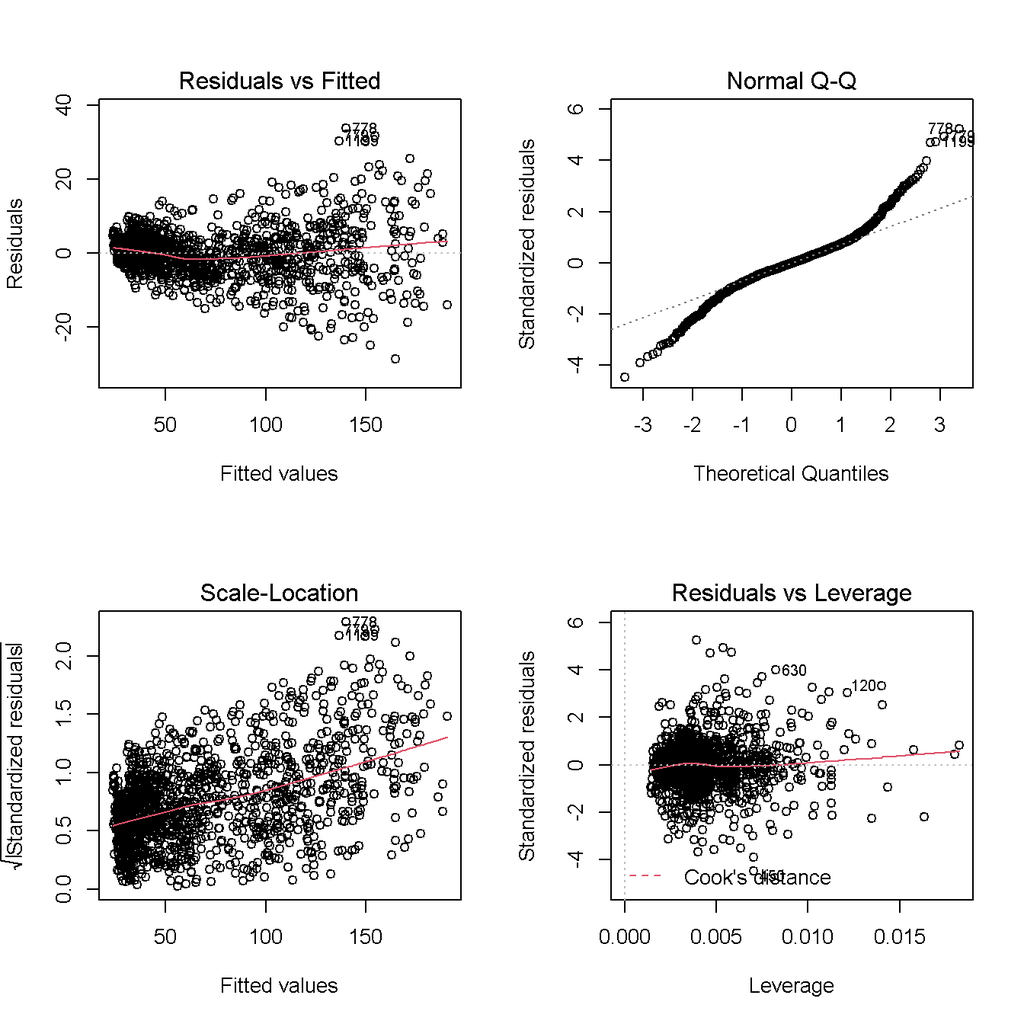

```r
par(mfrow = c(2, 2))
plot(estmodele)
```

# Deuxième modèle

Pour le deuxième modèle, nous allons donc enlever la variable population de plus de 16 ans.

Nous avons donc :

```r
modele2 <- cigar$prix ~ log(cigar$rdh) + cigar$priximin + cigar$an + cigar$ipc
estmodele2 <- lm(modele2, data = cigar)
summary(estmodele2)
```

```
##
## Call:
## lm(formula = modele2, data = cigar)
##
## Residuals:
##     Min      1Q  Median      3Q     Max
## -28.067  -3.288  -0.030   3.109  32.418
##
## Coefficients:
##                 Estimate Std. Error t value Pr(>|t|)
## (Intercept)    -15.77359    7.12952  -2.212   0.0271 *
## log(cigar$rdh)   4.53964    1.12807   4.024 6.03e-05 ***
## cigar$priximin   0.99542    0.01590  62.593  < 2e-16 ***
## cigar$an        -0.31226    0.13246  -2.357   0.0185 *
## cigar$ipc        0.08852    0.03204   2.763   0.0058 **
## ---
## Signif. codes:  0 '***' 0.001 '**' 0.01 '*' 0.05 '.' 0.1 ' ' 1
##
## Residual standard error: 6.597 on 1375 degrees of freedom
## Multiple R-squared:  0.9754, Adjusted R-squared:  0.9753
## F-statistic: 1.362e+04 on 4 and 1375 DF,  p-value: < 2.2e-16
```

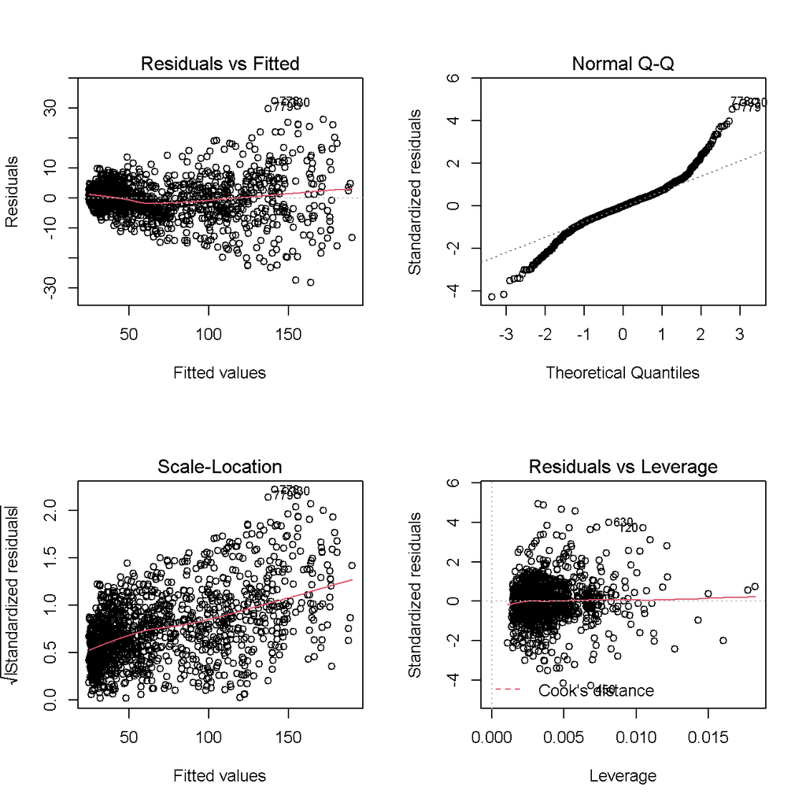

```r
par(mfrow = c(2, 2))
plot(estmodele2)
```

Ici nous avons un R carré ajusté de 0.9753, ce qui est inférieur à celui du premier modèle. Pour comparer les deux modèles, nous avons penser faire un test anova :

```r
anova(estmodele, estmodele2)
```

|  | Res.Df | RSS | Df | Sum of Sq | F | Pr(>F) |
| --- | --- | --- | --- | --- | --- | --- |
| 1 | 1374 | 57289.03 | NA | NA | NA | NA |
| 2 | 1375 | 59845.55 | -1 | -2556.517 | 61.31462 | 9.659957e-15 |

D’après le test Anova, nous avons bien le modèle 1 meilleur que le modèle 2 (sans la population de plus de 16 ans).

Nous garderons donc le premier modèle avec le logarithme de la population de plus de 16 ans.

# Troisième modèle

Avec les deux premiers modèles, nous avons remarqués que sur la variable explicative “rdh” l’erreur (Std. Error) était supérieur à 1 tandis que pour les autres variables l’erreur était proche de 0. Nous nous sommes penchés sur un troisième modèle sans cette variable, pour voir si elle est utile ou non dans le modèle.

```r
modele3 <- cigar$prix ~ cigar$priximin + cigar$an + cigar$ipc + log(cigar$pop16)
estmodele3 <- lm(modele3, data = cigar)
summary(estmodele3)
```

```
##
## Call:
## lm(formula = modele3, data = cigar)
##
## Residuals:
##     Min      1Q  Median      3Q     Max
## -29.180  -3.119  -0.112   3.059  34.004
##
## Coefficients:
##                    Estimate Std. Error t value Pr(>|t|)
## (Intercept)      -11.450853   6.246717  -1.833  0.06700 .
## cigar$priximin     0.990901   0.015336  64.615  < 2e-16 ***
## cigar$an          -0.001014   0.102145  -0.010  0.99208
## cigar$ipc          0.095608   0.031196   3.065  0.00222 **
## log(cigar$pop16)   1.427830   0.168039   8.497  < 2e-16 ***
## ---
## Signif. codes:  0 '***' 0.001 '**' 0.01 '*' 0.05 '.' 0.1 ' ' 1
##
## Residual standard error: 6.468 on 1375 degrees of freedom
## Multiple R-squared:  0.9763, Adjusted R-squared:  0.9763
## F-statistic: 1.418e+04 on 4 and 1375 DF,  p-value: < 2.2e-16
```

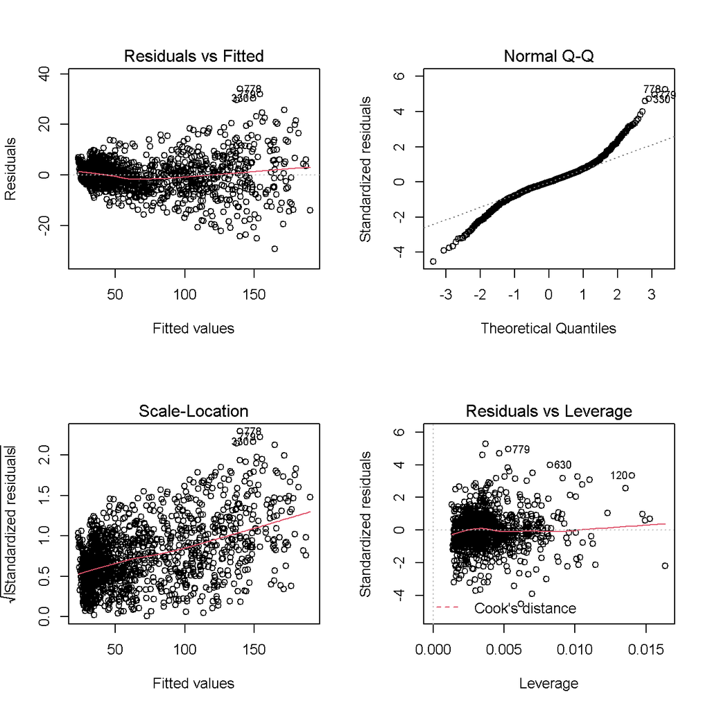

```r
par(mfrow = c(2, 2))
plot(estmodele3)
```

Avec ces données, on remarque que la variable du revenu disponible par habitant n’améliore pas le modèle. En conséquence, nous pouvons la retirer du modèle.

# Quatrième modèle

Après réflexion, nous nous sommes demandés si la variable “ventes” ne pouvait pas également influé sur le prix. Nous avons donc créé un quatrième modèle avec la variable “ventes”.

```r
modele4 <- cigar$prix ~ cigar$priximin + cigar$an + cigar$ipc + log(cigar$pop16) + cigar$ventes
estmodele4 <- lm(modele4, data = cigar)
summary(estmodele4)
```

```
##
## Call:
## lm(formula = modele4, data = cigar)
##
## Residuals:
##     Min      1Q  Median      3Q     Max
## -25.147  -3.056  -0.189   2.998  35.545
##
## Coefficients:
##                   Estimate Std. Error t value Pr(>|t|)
## (Intercept)      -6.323474   6.056753  -1.044 0.296652
## cigar$priximin    0.952328   0.015313  62.191  < 2e-16 ***
## cigar$an          0.073748   0.098966   0.745 0.456289
## cigar$ipc         0.107413   0.030161   3.561 0.000382 ***
## log(cigar$pop16)  1.146810   0.164772   6.960 5.26e-12 ***
## cigar$ventes     -0.058293   0.005852  -9.962  < 2e-16 ***
## ---
## Signif. codes:  0 '***' 0.001 '**' 0.01 '*' 0.05 '.' 0.1 ' ' 1
##
## Residual standard error: 6.249 on 1374 degrees of freedom
## Multiple R-squared:  0.9779, Adjusted R-squared:  0.9778
## F-statistic: 1.218e+04 on 5 and 1374 DF,  p-value: < 2.2e-16
```

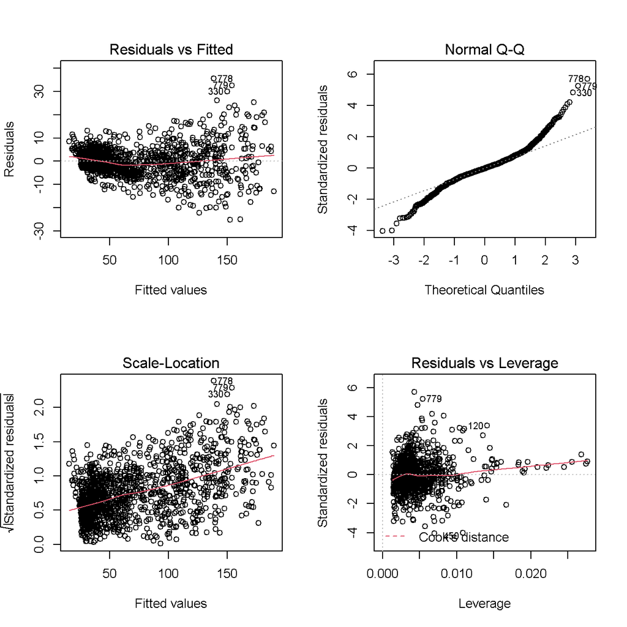

```r
par(mfrow = c(2, 2))
plot(estmodele4)
```

D’après les résultats, le modèle se serai amélioré car nous avons maintenant un R carré de 0.9778. Nous allons refaire un test anova pour certifier que ce modèle est meilleur.

```r
anova(estmodele3, estmodele4)
```

|  | Res.Df | RSS | Df | Sum of Sq | F | Pr(>F) |
| --- | --- | --- | --- | --- | --- | --- |
| 1 | 1375 | 57529.61 | NA | NA | NA | NA |
| 2 | 1374 | 53654.23 | 1 | 3875.383 | 99.24243 | 1.279052e-22 |

Grâce à ce test, on peut affirmer que le modèle 4 est donc plus pertinent que le modèle 3.

# Cinquième modèle

Nous avons décidé de tout passer au logarithme pour voir si on pouvait avoir un meilleur modèle, en faisant d’autres essais nous avons décider d’enlever la variable “année” et de rajouter la variable “rdh” (revenu disponible par habitant).

```r
modele5 <- log(cigar$prix) ~ log(cigar$priximin) + log(cigar$rdh) + log(cigar$ipc)+ log(cigar$pop16) + log(cigar$ventes)
estmodele5 <- lm(modele5, data = cigar)
summary(estmodele5)
```

```
##
## Call:
## lm(formula = modele5, data = cigar)
##
## Residuals:
##       Min        1Q    Median        3Q       Max
## -0.252199 -0.049996  0.001623  0.047627  0.275293
##
## Coefficients:
##                      Estimate Std. Error t value Pr(>|t|)
## (Intercept)          0.284168   0.059563   4.771 2.03e-06 ***
## log(cigar$priximin)  0.690142   0.014912  46.281  < 2e-16 ***
## log(cigar$rdh)       0.185609   0.013527  13.721  < 2e-16 ***
## log(cigar$ipc)       0.077711   0.020598   3.773 0.000168 ***
## log(cigar$pop16)     0.009073   0.002024   4.482 8.01e-06 ***
## log(cigar$ventes)   -0.203441   0.010446 -19.475  < 2e-16 ***
## ---
## Signif. codes:  0 '***' 0.001 '**' 0.01 '*' 0.05 '.' 0.1 ' ' 1
##
## Residual standard error: 0.07448 on 1374 degrees of freedom
## Multiple R-squared:  0.9832, Adjusted R-squared:  0.9831
## F-statistic: 1.606e+04 on 5 and 1374 DF,  p-value: < 2.2e-16
```

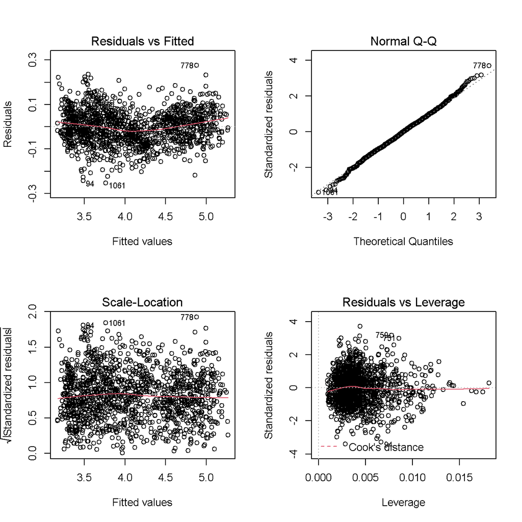

```r
par(mfrow = c(2, 2))
plot(estmodele5)
```

Avec un R carré de 0.9832, le modèle passé en logarithme est meilleur. Etudions ses graphiques par la suite.

# Graphiques

Revenons aux 4 graphiques du cinquième modèle.

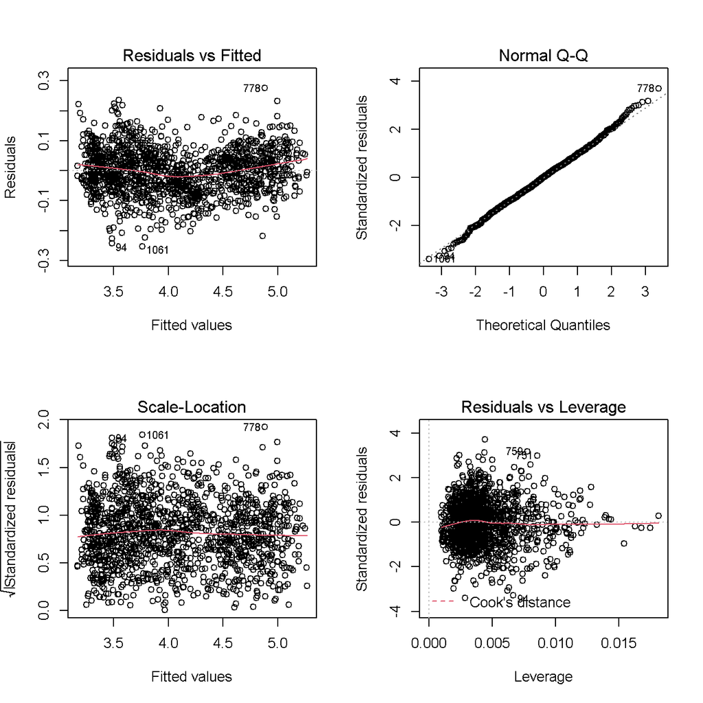

```r
par(mfrow = c(2, 2))
plot(estmodele5)
```

Le graphique “Residuals vs Fitted” montre la distribution en fonction des valeurs ajustées. Dans notre cas, nous n’observons pas de tendances à se regrouper, les résidus sont distribués de manières aléatoires autour de la droite de régression. Par conséquent, nous n’observons d’auto-corrélation des résidus. On en déduit que l’hypothèse de linéarité est accepté.

Le graphique “Scale-Location” affiche la variation de la variance des résidus standardisés en fonction des valeurs ajustées. Avec ce graphique, on observe que les résidus sont distribués de façon homogène et aléatoire autour de 0 tout au long du gradient des valeurs prédites ou pas. Ici la courbe rouge est globalement plate, cela signifie que la distribution des résidus est homogène et aléatoire autour de 0. Cela confirme l’observation faite par le premier graphique. L’hypothèse d’homoscedasticité est accepté et la variance des résidus est constante.

Le graphe “Normal Q-Q” : ce graphique montre si les résidus suivent une loi normale ici, on constate que certains points s’écartent de la ligne en pointillé. Pour être certain que les résidus suivent une loi normale, on a testé le modèle par le test de Shapiro-Wilk.

```r
shapiro.test(residuals(estmodele5))
```

```
##
##  Shapiro-Wilk normality test
##
## data:  residuals(estmodele5)
## W = 0.99834, p-value = 0.1991
```

La p-value étant supérieur à 0.05, l’hypothèse de la normalité est accepté.

Le dernier graphique “Residuals vs Leverage” représente l’effet levier de chaque point. Ici on constate que l’effet de levier n’est pas proche de 1. Cela montre qu’il y a une faible probabilitée de valeurs abhérantes.

# Conclusion

```r
summary(estmodele5)
```

```
##
## Call:
## lm(formula = modele5, data = cigar)
##
## Residuals:
##       Min        1Q    Median        3Q       Max
## -0.252199 -0.049996  0.001623  0.047627  0.275293
##
## Coefficients:
##                      Estimate Std. Error t value Pr(>|t|)
## (Intercept)          0.284168   0.059563   4.771 2.03e-06 ***
## log(cigar$priximin)  0.690142   0.014912  46.281  < 2e-16 ***
## log(cigar$rdh)       0.185609   0.013527  13.721  < 2e-16 ***
## log(cigar$ipc)       0.077711   0.020598   3.773 0.000168 ***
## log(cigar$pop16)     0.009073   0.002024   4.482 8.01e-06 ***
## log(cigar$ventes)   -0.203441   0.010446 -19.475  < 2e-16 ***
## ---
## Signif. codes:  0 '***' 0.001 '**' 0.01 '*' 0.05 '.' 0.1 ' ' 1
##
## Residual standard error: 0.07448 on 1374 degrees of freedom
## Multiple R-squared:  0.9832, Adjusted R-squared:  0.9831
## F-statistic: 1.606e+04 on 5 and 1374 DF,  p-value: < 2.2e-16
```

log(prix) = 0.28 + 0.69 * log(prixmin) + 0.19 * log(rdh) + 0.08 * log(IPC) + 0.01 * log(Pop +16) - 0.20 * log(ventes) Ce modèle a un R carré ajusté de 0.9832. Avec les études sur ce modèle, on peut conclure que ce modèle est bon pour estimer le prix par paquet de cigarettes selon les variables explicatives choisies.